## STATS 531 Midterm Project

## Are Time Series Models Adaptive to Sudden Swings in Annual Premiums for Smoker and Non-smoker Class Policyholders? (1999-2009)

**Loading packages**

```r
library(ggplot2)
library(dplyr)
library(gridExtra)
library(xts)
library(sp)
library(zoo)
library(CASdatasets)
library(tseries)
library(forecast)
#install.packages("CASdatasets", repos = "http://cas.uqam.ca/pub/R/", type="source")
```

**Data Pre-processing**  
To begin, we only consider the variables “issue.date”, “risk.state”, and “annual.premium” for whole life policies that require ANNUAL PAYMENTS and those that DO NOT COVER ACCIDENTAL DEATHS. “issue.date” indicates the date that the whole life policy is issued; “risk.state” classifies the policyholder as a smoker or an non-smoker; “annual.premium” specifies the standardized annual premium that the policyholders pay. The annual premium amount is standardized with mean=560.88 and standard deviation=526.58. We may tranform the annual premium amount back to its non-standardized form for the sake of clarity and crudity. We did exactly this. We start by filtering the “premium.frequency” status to be “Annual” to contain policies with only annual premium payments, and distill the “acc.death.rider” status to be “NoRider” to limit the policies to contain no accidental death coverages. Only policies issued from 1999 to 2009 are used. Later, we seperate the data into two categories: One containing whole life insurance policies issued to smokers and the other one containing whole life insurance policies issued to non-smokers. We then compare the annual premiums of the policies written on the same days for smokers and non-smokers to avoid time bias. Each day, annual premiums of policies are averaged to represent the annal premiums written on that day. We have now reduced the number of data points for the “Smoker” class from 10843 to 333 and for the “NonSmoker” class from 18474 to 333.The data is cleaned and we move on to exploring them. To remove the extreme outliers, we replace the annual premium data points that lie outside of the 1.5*IQR limit with the 5th percentile and 95th percentile values.

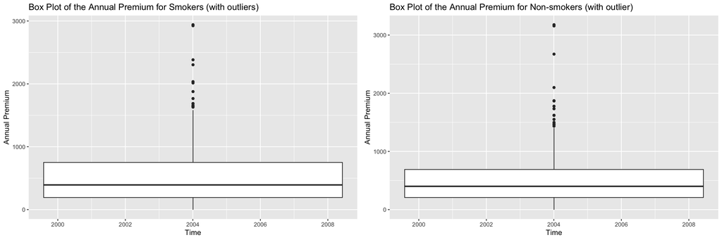

```r
data(uslapseagent)
#Filtering the policies issued from 1999 to 2009 with ANNUAL PAYMENTS and NO ACCIDENTAL DEATH COVERAGES
uslapseagent=uslapseagent%>%filter(issue.date>="1999-02-02",premium.frequency=="Annual"&acc.death.rider=="NoRider")
# Select the variables to be considered
uslapseagent=uslapseagent[,c("issue.date","risk.state","annual.premium")]
# De-standardizing the premium amount for the sake of clarity and crudity
uslapseagent$annual.premium=uslapseagent$annual.premium*526.58+560.88
# Filtering the data so that one data frame contains policies written to smokers and the other one contains policies written to non-smokers
smoker.prem=uslapseagent%>%filter(risk.state=="Smoker")
nonsmoker.prem=uslapseagent%>%filter(risk.state=="NonSmoker")
# We unify the dates for which the policies are issued to both smoker and non-smokers to avoid time bias. There may be multiple policies issued to both smokers and non-smokers in one day.
common.dates=as.Date(intersect(factor(smoker.prem$issue.date),factor(nonsmoker.prem$issue.date)))
smoker.prem=smoker.prem%>%filter(issue.date%in%common.dates)
nonsmoker.prem=nonsmoker.prem%>%filter(issue.date%in%common.dates)

# Averaging multiple policies issued to both smokers and non-smokers in one day
avgmultpol=function(x){
  dupInd=which(duplicated(x[,1]))
  for (i in 1:length(dupInd)){
    dupAvg=mean(x[,3][which(x[,1]==x[,1][dupInd[i]])])
    x[,3][which(x[,1]==x[,1][dupInd[i]])]=dupAvg
  }
  x[!duplicated(x[,1]),]
}
smoker.prem=avgmultpol(smoker.prem)
nonsmoker.prem=avgmultpol(nonsmoker.prem)

# Plotting boxplots to examine the outliers of the annual premium amount for smokers and non-smokers
plt1=ggplot(data=smoker.prem,aes(x=issue.date,y=annual.premium,group=1))+geom_boxplot()+labs(title="Box Plot of the Annual Premium for Smokers (with outliers)",x="Time",y="Annual Premium")
plt2=ggplot(data=nonsmoker.prem,aes(x=issue.date,y=annual.premium,group=1))+geom_boxplot()+labs(title="Box Plot of the Annual Premium for Non-smokers (with outlier)",x="Time",y="Annual Premium")
grid.arrange(plt1,plt2,ncol=2)
```

```r
# Removing the outliers by capping values at the 5% and the 95% quantiles
# set inter-quantile values
s.qnt=quantile(smoker.prem$annual.premium,probs=c(0.25,0.75))
ns.qnt=quantile(nonsmoker.prem$annual.premium,probs=c(0.25,0.75))
# set replacement values
s.caps=quantile(smoker.prem$annual.premium,probs=c(0.05,0.95))
ns.caps=quantile(nonsmoker.prem$annual.premium,probs=c(0.05,0.95))
# set cutoff values
s.lim=1.5*IQR(smoker.prem$annual.premium)
ns.lim=1.5*IQR(nonsmoker.prem$annual.premium)
# replacing data with capping
smoker.prem$annual.premium[smoker.prem$annual.premium>s.qnt[[2]]+s.lim]=s.caps[[2]]
nonsmoker.prem$annual.premium[nonsmoker.prem$annual.premium>ns.qnt[[2]]+ns.lim]=ns.caps[[2]]
smoker.prem$annual.premium[smoker.prem$annual.premium<s.qnt[[1]]-s.lim]=s.caps[[1]]
nonsmoker.prem$annual.premium[nonsmoker.prem$annual.premium<ns.qnt[[1]]-ns.lim]=ns.caps[[1]]
```

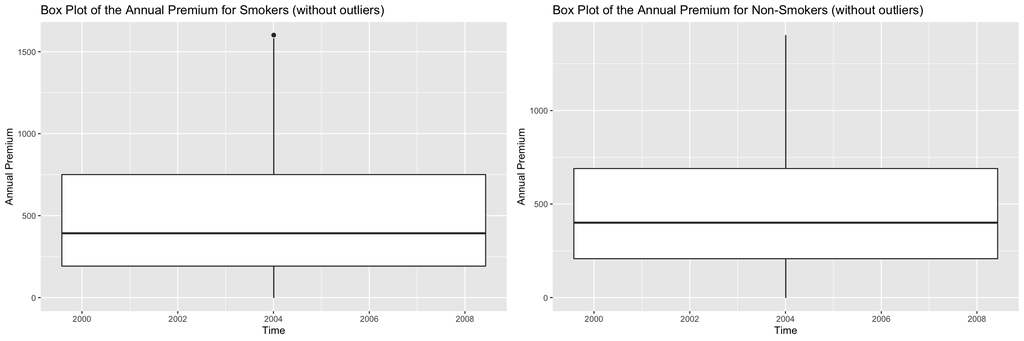

```r
#Visualizing with boxplots
plt3=ggplot(data=smoker.prem,aes(x=issue.date,y=annual.premium,group=1))+geom_boxplot()+geom_boxplot()+labs(title="Box Plot of the Annual Premium for Smokers (without outliers)",x="Time",y="Annual Premium")
plt4=ggplot(data=nonsmoker.prem,aes(x=issue.date,y=annual.premium,group=1))+geom_boxplot()+geom_boxplot()+labs(title="Box Plot of the Annual Premium for Non-Smokers (without outliers)",x="Time",y="Annual Premium")
grid.arrange(plt3,plt4,ncol=2)
```

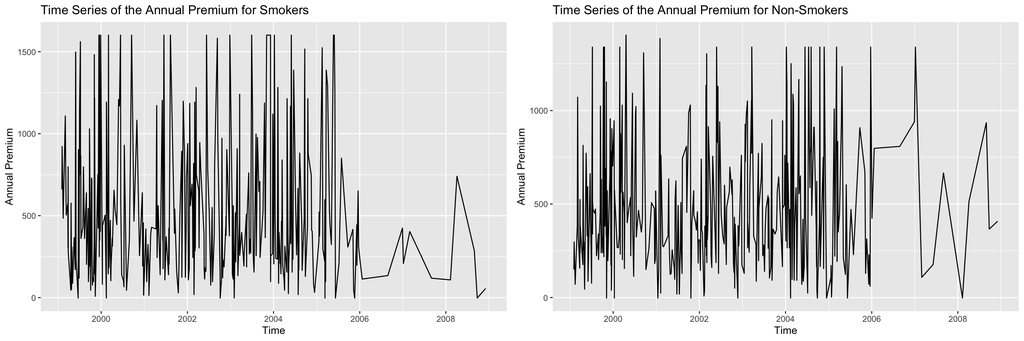

```r
# Vizualizing with time plots
plt5=ggplot(data=smoker.prem,aes(x=issue.date,y=annual.premium,group=1))+geom_line()+labs(title="Time Series of the Annual Premium for Smokers",x="Time",y="Annual Premium")
plt6=ggplot(data=nonsmoker.prem,aes(x=issue.date,y=annual.premium,group=1))+geom_line()+labs(title="Time Series of the Annual Premium for Non-Smokers",x="Time",y="Annual Premium")
grid.arrange(plt5,plt6,ncol=2)
```

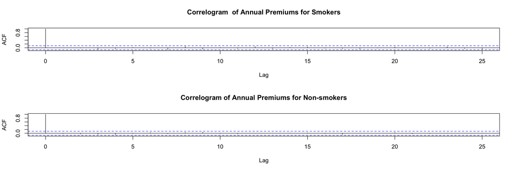

```r
# Visualizing correlogram
par(mfrow=c(2,1))
acf(smoker.prem$annual.premium, type=c("correlation"),main="Correlogram  of Annual Premiums for Smokers")
acf(nonsmoker.prem$annual.premium, type=c("correlation"),main="Correlogram of Annual Premiums for Non-smokers")
```

**Testing for Stationarity**  
To fit stationary models for further analyses, we require the data to be stationary. From the Augmented Dickey-Fuller (ADF) Test, we reject the null hypothesis of non-stationarity for smokers and non-smokers annual premium series at p-value=0.01, and conclude that both series are stationary. The sharp decay in the autocorrelation plots above is also a phenomenon of a stationary time series.

```r
# ADF test for smokers
adf.test(smoker.prem$annual.premium,alternative="stationary")
```

```
##
##  Augmented Dickey-Fuller Test
##
## data:  smoker.prem$annual.premium
## Dickey-Fuller = -8.2987, Lag order = 6, p-value = 0.01
## alternative hypothesis: stationary
```

```r
# ADF test for non-smokers
adf.test(nonsmoker.prem$annual.premium,alternative="stationary")
```

```
##
##  Augmented Dickey-Fuller Test
##
## data:  nonsmoker.prem$annual.premium
## Dickey-Fuller = -7.6796, Lag order = 6, p-value = 0.01
## alternative hypothesis: stationary
```

**Fitting Stationary ARMA(p,q) Model**  
The Akaike Information Criterion (AIC) is a quantity that measures the predictability of a model while penalizing large number of parameters to discourage overfitting. It has a maximum likelihood component denoted by $\hat{L}$ and a number of paramenters component denoted by $k$. The quantity is written as $AIC=2k-2ln(\hat{L})$. Here, we use AIC to select the best ARMA model. To do this, we create AIC tables to compare the AIC values between different ARMA models, for fitting annual premiums for smokers and non-smokers.

```r
# Using AIC to select p and q
# Creating a function to construct AIC table for smoker annual premiums
smokerAIC=function(data,P,Q){
  table=matrix(NA,(P+1),(Q+1))
  for(p in 0:P){
    for(q in 0:Q){
      table[p+1,q+1]=arima(smoker.prem$annual.premium,order=c(p,0,q))$aic
    }
  }
  dimnames(table)=list(paste("AR",0:P,sep=""),paste("MA",0:Q,sep=""))
  table
}
# Creating a function to construct AIC table for non-smoker annual premiums
nonsmokerAIC=function(data,P,Q){
  table=matrix(NA,(P+1),(Q+1))
  for(p in 0:P){
    for(q in 0:Q){
      table[p+1,q+1]=arima(nonsmoker.prem$annual.premium,order=c(p,0,q))$aic
    }
  }
  dimnames(table)=list(paste("AR",0:P,sep=""),paste("MA",0:Q,sep=""))
  table
}
```

We inspect the AIC table for smoker annual premiums and observe the ARMA(0,0) model has the lowest AIC value at 5002.112.

```r
as.data.frame(smokerAIC(smoker.prem$annual.premium,5,5))
```

```
##          MA0      MA1      MA2      MA3      MA4      MA5
## AR0 5002.112 5004.108 5005.992 5005.617 5006.168 5008.008
## AR1 5004.108 5006.106 5003.374 5005.076 5008.020 5009.972
## AR2 5006.000 5003.346 5005.294 5006.920 5006.864 5008.542
## AR3 5005.777 5005.170 5006.987 5004.430 5006.424 5007.669
## AR4 5006.925 5008.838 5007.446 5006.094 5007.588 5009.681
## AR5 5008.839 5010.813 5010.190 5007.669 5009.752 5011.081
```

We inspect the AIC table for non-smoker annual premiums and observe the ARMA(4,3) model has the lowest AIC value at 4864.730.

```r
as.data.frame(nonsmokerAIC(nonsmoker.prem$annual.premium,5,5))
```

```
##          MA0      MA1      MA2      MA3      MA4      MA5
## AR0 4864.735 4866.499 4867.418 4867.967 4867.935 4869.885
## AR1 4866.523 4865.855 4867.195 4868.742 4869.916 4871.278
## AR2 4867.733 4867.110 4867.845 4871.083 4868.498 4867.559
## AR3 4868.441 4868.487 4869.697 4869.914 4864.754 4873.854
## AR4 4867.941 4869.631 4871.583 4864.730 4867.455 4873.653
## AR5 4869.481 4870.893 4872.278 4873.637 4869.882 4873.931
```

Here, we fit ARMA(0,0) model for smokers annual premium based on the smallest AIC measure. Note that this is a white noise model.

```r
smoker.prem.arma00=arima(smoker.prem$annual.premium,order=c(0,0,0))
smoker.prem.arma00
```

```
##
## Call:
## arima(x = smoker.prem$annual.premium, order = c(0, 0, 0))
##
## Coefficients:
##       intercept
##        524.2176
## s.e.    24.0868
##
## sigma^2 estimated as 193198:  log likelihood = -2499.06,  aic = 5002.11
```

Here, we fit ARMA(4,3) model for non-smokers annual premium based on the smallest AIC measure.

```r
nonsmoker.prem.arma43=arima(nonsmoker.prem$annual.premium,order=c(4,0,3))
nonsmoker.prem.arma43
```

```
##
## Call:
## arima(x = nonsmoker.prem$annual.premium, order = c(4, 0, 3))
##
## Coefficients:
##          ar1      ar2     ar3      ar4      ma1     ma2      ma3
##       0.2344  -0.7734  0.5234  -0.0734  -0.2619  0.7613  -0.6368
## s.e.  0.2346   0.1191  0.2260   0.0626   0.2313  0.0875   0.2306
##       intercept
##        487.0793
## s.e.    15.1433
##
## sigma^2 estimated as 121057:  log likelihood = -2423.36,  aic = 4864.73
```

We examine the roots of the AR and MA components to check for causality and invertibility, respectively. We examine causality to check if the time series is dependent on past values, and look out for invertibility to distinguish unique or non-unique models. Although the ARMA (0,0) model is suggested for estimating the annual premium for smokers, it does not serve for causality or invertibility because of its white noise properties. To state simply, its roots do not exist.  
*Fitting ARMA(2,1) model for smokers annual premium and examining its roots*  
We examine the ARMA(2,1) model instead, which has the second smallest AIC value at 5003.346. Here, the AR roots outside of the unit circle implies a causal process, as the MA roots outside of the unit circle implies an invertible process.

```r
# Fitting ARMA(2,1) model for smokers annual premium
smoker.prem.arma21=arima(smoker.prem$annual.premium,order=c(2,0,1))
# Exploring the AR roots to determine causaliity
polyroot(c(1,-coef(smoker.prem.arma21)[c("ar1","ar2")]))
```

```
## [1]  1.097109+0i 22.365811+0i
```

```r
# Exploring the MA roots to determine inveritbility
polyroot(c(1,-coef(smoker.prem.arma21)[c("ma1")]))
```

```
## [1] -1.033007+0i
```

```r
# Exploring the AR roots to determine causaliity
polyroot(c(1,-coef(nonsmoker.prem.arma43)[c("ar1","ar2","ar3","ar4")]))
```

```
## [1] -0.201471+1.025135i -0.201471-1.025135i  2.459412+0.000000i
## [4]  5.077819-0.000000i
```

```r
# Exploring the MA roots to determine inveritbility
polyroot(c(1,-coef(nonsmoker.prem.arma43)[c("ma1","ma2","ma3")]))
```

```
## [1]  0.9935037+0.9984848i -0.7915301-0.0000000i  0.9935037-0.9984848i
```

```r
# Fitting ARMA(1,1) model for non-smokers annual premium
nonsmoker.prem.arma11=arima(nonsmoker.prem$annual.premium,order=c(1,0,1))
# Exploring the AR roots to determine causaliity
polyroot(c(1,-coef(nonsmoker.prem.arma11)[c("ar1")]))
```

```
## [1] 1.361402+0i
```

```r
# Exploring the MA roots to determine inveritbility
polyroot(c(1,-coef(nonsmoker.prem.arma11)[c("ma1")]))
```

```
## [1] -1.252775+0i
```

Ultimately, we choose to fit the smokers annual premium with the ARMA(2,1) model and to fit the non-smokers annual premium with the ARMA(1,1) model. We learned that although AIC is a fair measure for model complexity vs predictability, it is also benefitial to select models that are casaul and invertible for the sake of predictability and reliablity.

*Residual Analysis*  
The residuals for both the ARMA(2,1) and ARMA(1,1) models fall within the bounds in the autocorrelation (ACF) graph and do not seem to have great significance. This shows signs of accuracy for fitting the ARMA(2,1) model on smokers annual premium and the ARMA(1,1) model on non-smokers annual premium.

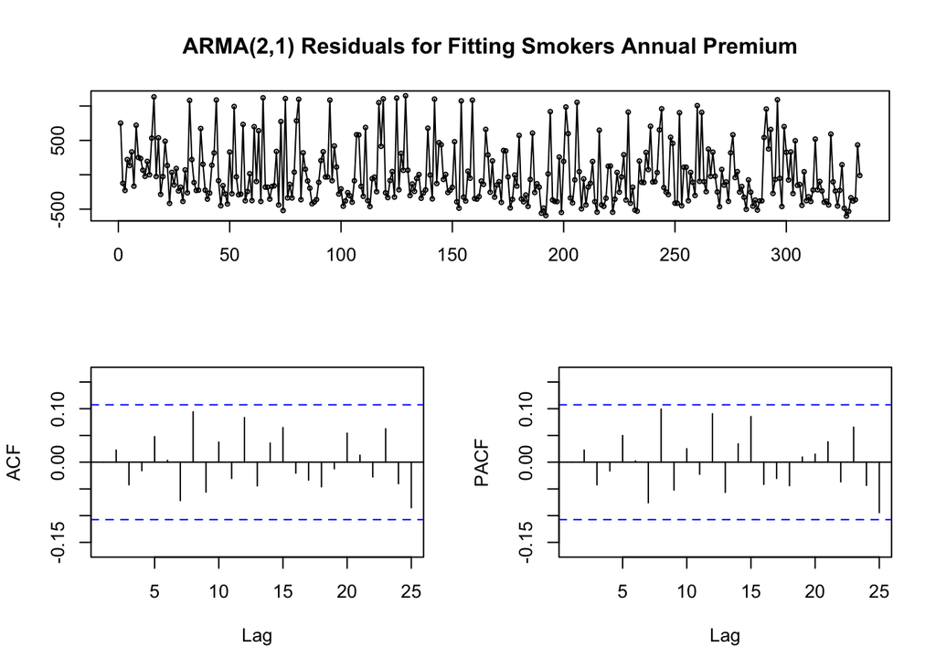

```r
# Residuals on fitting ARMA(2,1) model on smokers annual premium
tsdisplay(residuals(smoker.prem.arma21),main="ARMA(2,1) Residuals for Fitting Smokers Annual Premium")
```

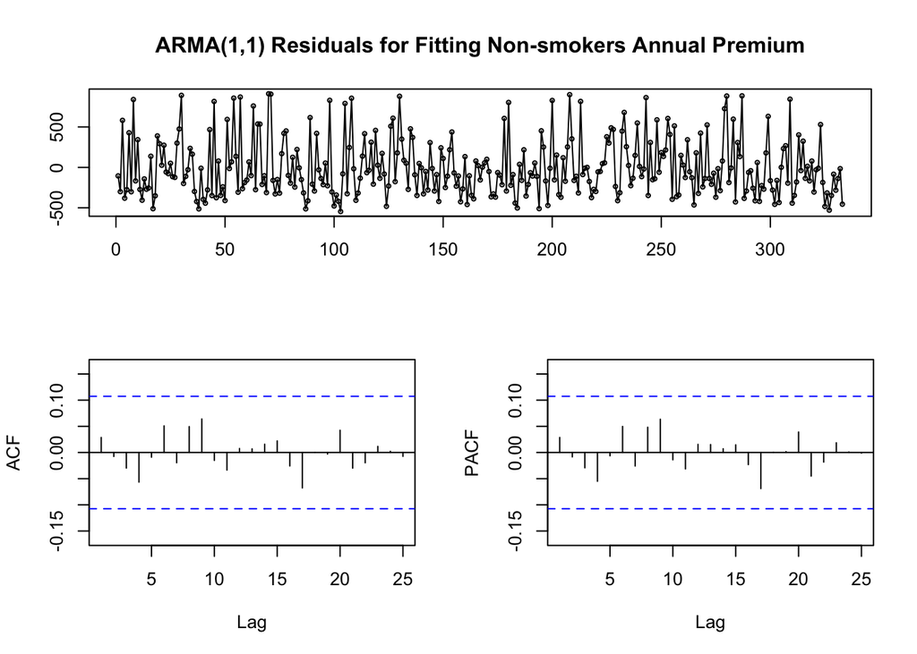

```r
# Residuals on fitting ARMA(1,1) model on non-smokers annual premium
tsdisplay(residuals(nonsmoker.prem.arma11),main="ARMA(1,1) Residuals for Fitting Non-smokers Annual Premium")
```

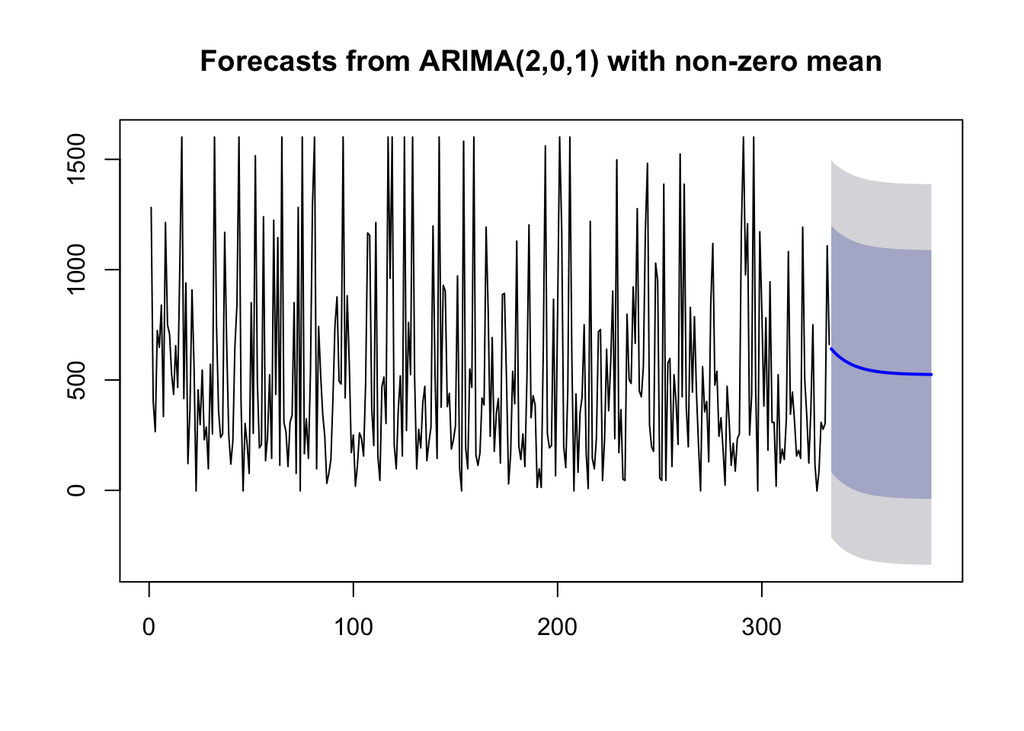

```r
# The average annual premiums for whole policies written for smokers in the next 50 days
plot(forecast(smoker.prem.arma21,h=50))
```

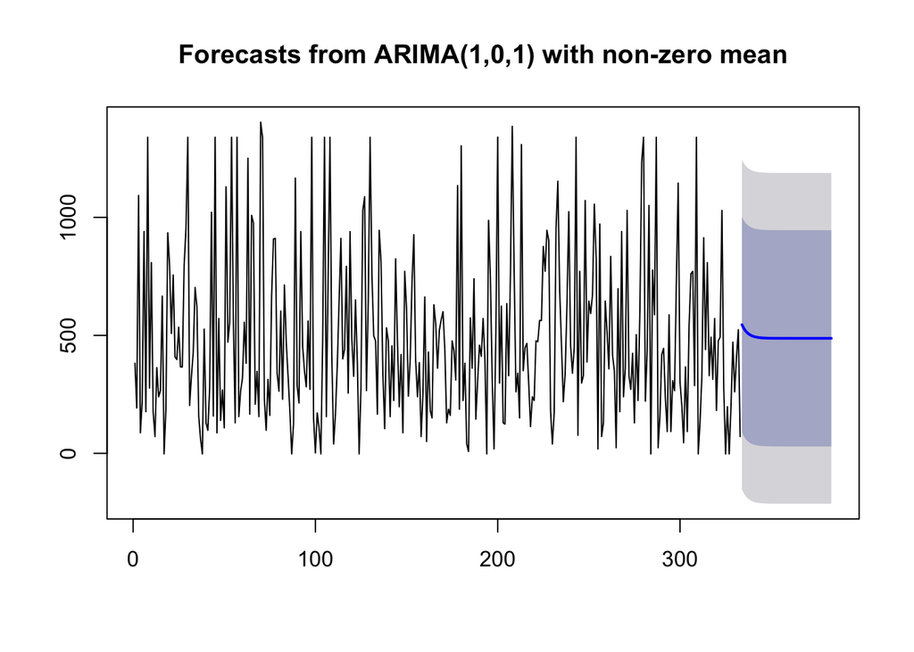

```r
# The average annual premiums for whole policies written for non-smokers in the next 50 days
plot(forecast(nonsmoker.prem.arma11,h=50))
```

**Spectral Analysis**  
We smoothed the original periodograms 3 times with different moving average smoothers in order to remove the background noise of the time series. The frequency of each periodogram is 10 cycles per unit time as the period for each periodogram is 1/10. The spectral density for the smokers annual premium consists of 7 distinct peaks with different spaces.; this means that the annual periodic component is sinusoidal. The peaks are centered around the 275000 level of the power spectrum (denoted by the red dashed line), and seem to occur during irregular cycles. The spectral density for the non-smokers annual premium consists of 3 major peaks at around 0.14,0.21, and 0.33 frequency levels with the maximum hitting ariund 200000 power spectrum. Each of the hiking patterns seems to take up one cycle. We compare both periodograms and find that the peak powers are more extreme for the smokers annual premium. This means that the autocovariances and thus, the autocorrelations for smokers annual premium are higher.

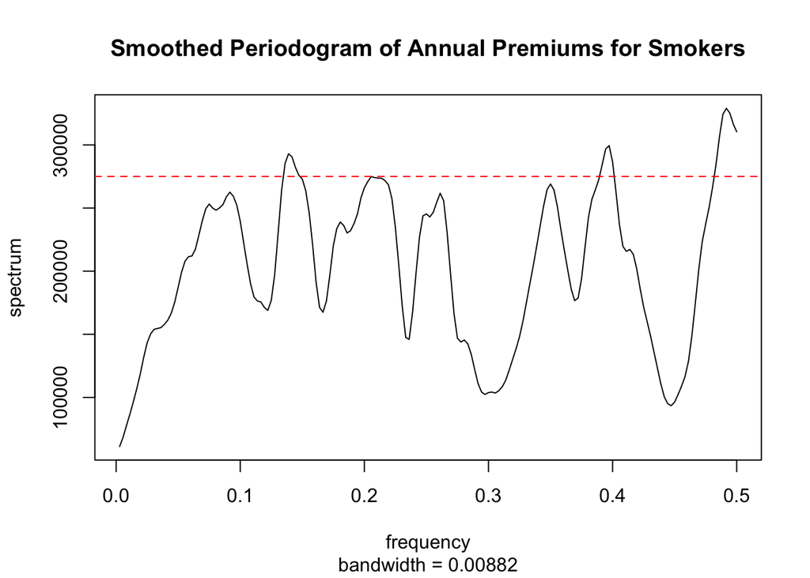

```r
# Smoothed periodogram of smokers annual premium
spectrum(smoker.prem$annual.premium, log="no",spans=c(5,10), main="Smoothed Periodogram of Annual Premiums for Smokers")
abline(h=275000,lty="dashed",col="red")
```

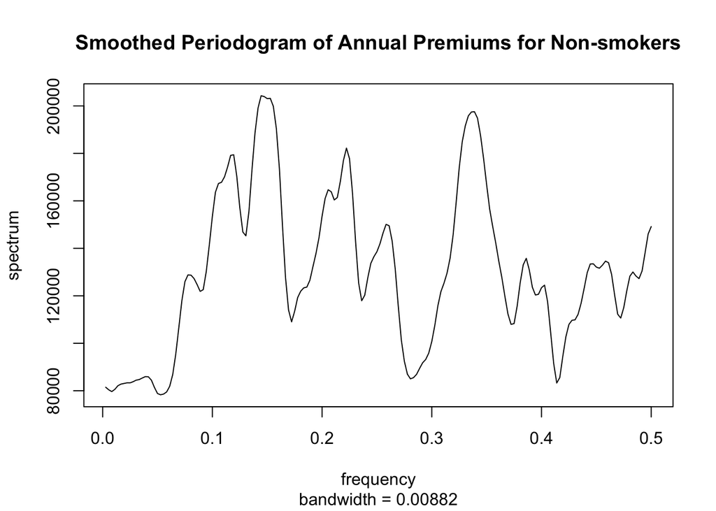

```r
# Smoothed periodogram of non-smokers annual premium
spectrum(nonsmoker.prem$annual.premium, log="no", spans=c(5,10), main="Smoothed Periodogram of Annual Premiums for Non-smokers")
```

*Estimating Trend by Loess Smoothing*  
We set span=0.1 here and observe that the loess smoothing method estimates the trend of the original series very well. For smokers annual premium, loess follows the fluctuating trend from 1999 to 2006 then flags at a lower level thereafter. For non-smokers annual premium, loess fluctuates similarly until 2006, then rises to catch the hike before dropping down to a lower level.

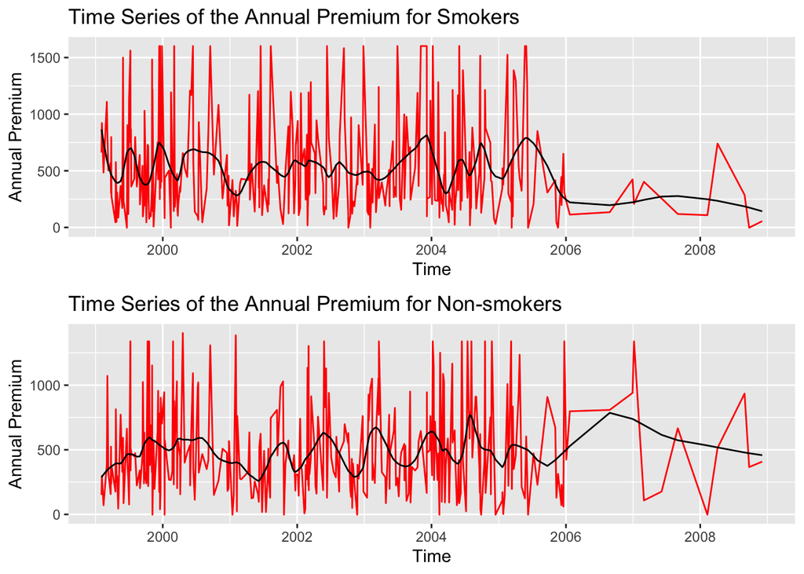

```r
# Loess smoothing for smoker annual premium
smoker.loess=loess(annual.premium~as.numeric(issue.date),data=smoker.prem,span=0.1)
plt7=ggplot(data=smoker.prem,aes(x=issue.date,y=annual.premium,group=1))+geom_line(color="red")+geom_line(aes(x=smoker.prem$issue.date,y=smoker.loess$fitted),color="black",linetype="solid")+labs(title="Time Series of the Annual Premium for Smokers",x="Time",y="Annual Premium")
# Loess smoothing for non-smoker annual premium
nonsmoker.loess=loess(annual.premium~as.numeric(issue.date),data=nonsmoker.prem,span=0.1)
plt8=ggplot(data=nonsmoker.prem,aes(x=issue.date,y=annual.premium,group=1))+geom_line(color="red")+geom_line(aes(x=nonsmoker.prem$issue.date,y=nonsmoker.loess$fitted),color="black",linetype="solid")+labs(title="Time Series of the Annual Premium for Non-smokers",x="Time",y="Annual Premium")
grid.arrange(plt7,plt8,nrow=2)
```

**Conclusion**  
After our analysis, we found ARMA(2,1) as the proper model for estimating the smokers annual premiums, and ARMA(1,1) as the proper model for estimating the non-smokers annual premiums. Both models are fitted to forecast a resulting downward trend for annual premiums for different risk status, which is what we expect. This means that whether or not the insurance companies change their underwritting schemes, we are still able to predict the trend of the annual premiums based on the passage of time. In other words, as time goes on, the behaviors of the society may change, but we are still able to get adaptable results in time series that reflects the changes. In the above case, the downward forecasts reflect changes in society’s behaviors, and because smokers annual premium (not just non-smokers annual premium ) also displays such forcast property, these behaviors are not only caused by a reduction in smoking activities. To conclude, time series models, at least the ones listed, are adaptive to sudden swings in annual premiums for smoker and non-smoker class policyholders.

**References**  
(1) Dataset used in Milhaud and Dutang (2018), Lapse tables for lapse risk management in insurance: a competing risk approach, European Actuarial Journal, 2018, Volume 8, Issue 1.  
(2) Xavier Milhaud, Christophe Dutang. Lapse tables for lapse risk management in insurance: a competing risk approach. European Actuarial Journal, Springer, 2018, 8 (1), pp.97-126.  
(3) http://dutangc.free.fr/pub/RRepos/web/CASdatasets-manual.pdf  
(4)https://www.iii.org/press-release/life-insurance-premiums-expected-to-decline-by-4-percent-in-2007-says-the-insurance-information-institute-091906